# A machine learning approach to House Price Indexes with the hpiR package

Andy Krause – Zillow Group – Seattle, WA

2019-03-05

### Abstract

Real estate price indexes are widely used across many different property types, use cases and research designs. This paper is divided into three parts. In the first, I provide an overview of the recently released open source package, **hpiR**, (R language) for calculating house price indexes. Along with this, I cover the development of a consistent terminology and concepts to discuss and compare indexes. In part two, I introduce a new method or approach for estimating a home price index: Random Forest simulations. Finally, in the third section I highlight hte functionality of the **hpiR** package by comparing the performance of the Random Forest-generated indexes to more traditional Repeat Sales- and Hedonic Price Model-derived indexes.

## Part 1: Concepts and Functionality

This initial section covers the key concepts and functionality of the `hpiR` package (v0.3.0), including discussion of terminology and included datasets. For more in-depth information on the development of the package or to examine the history of code changes please see the additional resources below:

- More information on this package’s development can be found at www.github.com/andykrause/hpiR.
- The official CRAN repository page is located at: https://cran.r-project.org/web/packages/hpiR/index.html
- A detailed explanation of the class and method structure employed in this package can be found in the **Classes in hpiR** vignette in this package, or at: https://cran.r-project.org/web/packages/hpiR/vignettes/classstructure.html

#### Terminology

The following terms are used through the `hpiR` package, its documentation, and this paper:

- **Index**: a time-series of values estimating the movement of prices over time with a base period value of 100
- **Series**: progression of increasing longer indexes, each one adding one more time period than the previous
- **Model**: statistical or other type of mathematical equation or algorithm used to generate the raw coefficient (or other) estimates that are converted into the scaled (base = 100) index values
- **Accuracy**: ability of an index to represent the actual market movements
- **Volatility**: measure of the period to period movement in index values
- **Smooth**: reduce volatility with a rolling average or similar smoothing process
- **Revision**: amount that the index value for a specific period moves over the course of a **series**

### Functionality

The `hpiR` package is designed to provide standardized process that encompass all of the common steps in producing a house price index. In general order of execution these are:

1. **Data Preparation**: Converting transaction data into a format useable by one or more of the available models
2. **Modeling**: Estimate a statistical (or other) model to derive raw coefficient or price movements
3. **Index Creation**: Converting model output into a standardized index with base 100
4. **Analysis: Index-level**: Assessing the quality of index
   - **Volality** - Period to period movement
   - **In-Sample Accuracy** - Ability of the model to accurately prediction the second sales in a repeat sales pair (with no holdout structure)
   - **K-Fold Out-of-Sample Accuracy** - Ability of the model to accurately prediction the second sales in a repeat sales pair (with a k-fold holdout structure)
5. **Series Creation** - Building a sequentially longer set of indexes using the same model and an increasing (over time) dataset
6. **Analysis: Series-level**: Assessing the quality of a series
   - **Volatility** - Period to period movement in each index of the series
   - **Revision** - Amount that the value of each period changes when new data and a new index is added to the series
   - **Prediction Out-of-Sample Accuracy** - Ability of the model to accurately prediction the second sales in a repeat sales pair (with a forward prediction holdout structure)

### Package Basics

The `hpiR` package is written for the R statistical language. The stable version of this package can be obtained by installing from the Comprehensive R Archive Netwok (CRAN) from within R with the following command:

```r
  install.packages('hpiR')
```

If you want the most up-to-date, development version this can be downloaded directly from my Github repository with (ensure that you have the `devtools` package installed first as well):

```r
   devtools::install_github("andykrause/hpiR")
```

Once you have have installed it, load it like you would any other package: `library(hpiR)`

#### Data

This package provides two sample datasets to work with. The first, `seattle_sales`, includes over 43,000 sales of single family homes and townhouses within the City of Seattle over the 2010 to 2016 time frame. The second, `ex_sales` is a subset of the first, encompassing only the central area of the city. This more limited set of data contains about 5,300 transactions over the same time period. The source of the data is the King County Assessor’s office.[^1] The data is open and free to share.

The data can be loaded with the `data(seattle_sales)` and `data(ex_sales)` commands. We will work with the `ex_sales` object in this vignette.

```r
  data(seattle_sales)

  data(ex_sales)
```

The data includes the following information for all transactions:

| Field Name | Type | Example | Description |
| --- | --- | --- | --- |
| pinx | chr | ..0007600046 | Tax assessor parcel identification number |
| sale_id | chr | 2011..2621 | Unique sale identifier |
| sale_price | integer | 308900 | Sale price |
| sale_date | Date | 2011-02-22 | Date of sale |
| use_type | factor | sfr | Structure type |
| area | factor | 15 | Tax assessor defined neighborhood or area |
| lot_sf | integer | 5160 | Size of lot in square feet |
| wfnt | binary | 1 | Is the property waterfront? |
| bldg_grade | integer | 8 | Structure building quality |
| tot_sf | integer | 2200 | Total finished square feet of the home |
| beds | integer | 3 | Number of bedrooms |
| baths | numeric | 2.5 | Numbrer of bathrooms |
| age | integer | 100 | Age of home |
| eff_age | integer | 12 | Years since major renovation |
| longitude | numeric | -122.30254 | Longitude |
| latitude | numeric | 47.60391 | Latitude |

## Random Forest House Price Indexes

With the use of simulations, however, price trends can be extracted from random forest models as used to create an index. In general, the process works like this:

1. Estimate a random forest model (including a time period variable in the specification)
2. Create a hypothetical observation with transaction dates at every available period in your model
3. Predict the value of these observation at each period using the random forest
4. Convert this series of price predictions to a index
5. Repeat steps 2 through 4 multiple times and average the results

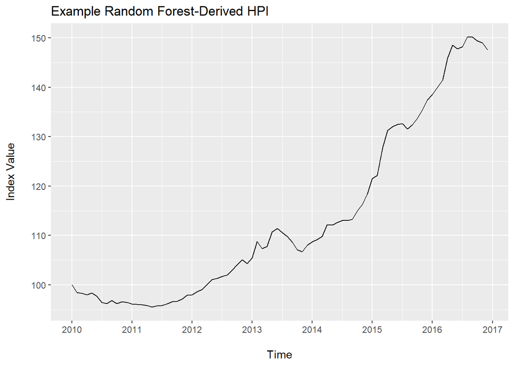

```r
  readRDS('c:/code/research/hpir/papers/ex1plot.rds')
```

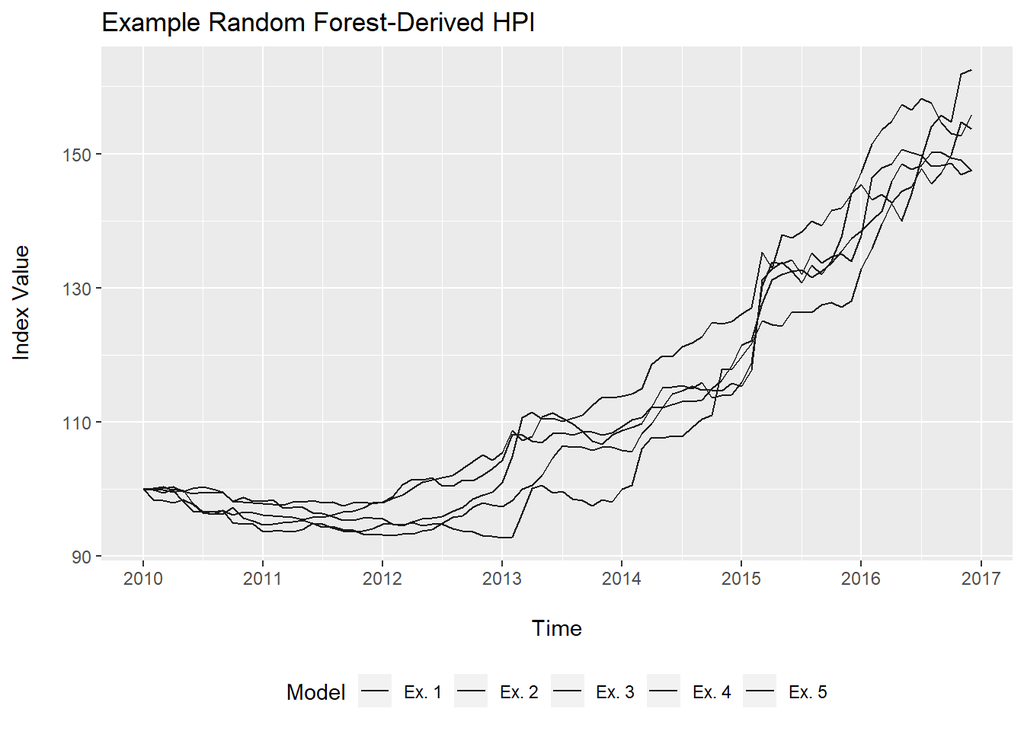

```r
   readRDS('c:/code/research/hpir/papers/ex15plot.rds')
```

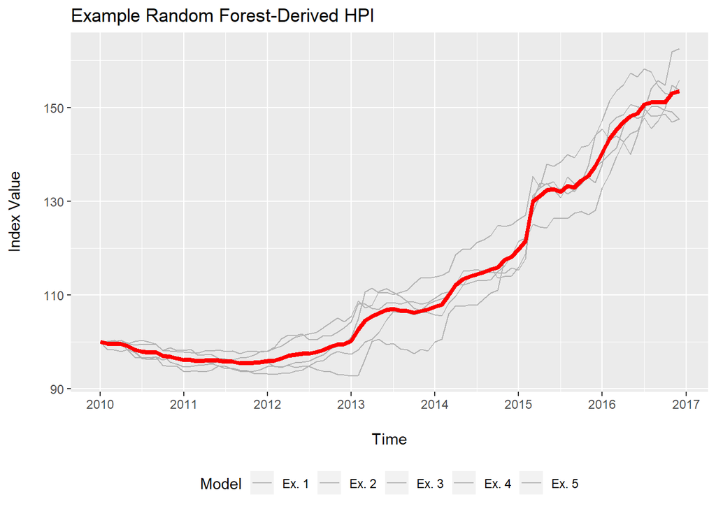

```r
   readRDS('c:/code/research/hpir/papers/ex15aplot.rds')
```

## Comparative Analysis

In this section I highlight the functionality of the `hpiR` package by using it to compare the ‘quality’ of the price index (and related series) generated by the Random Forest method with those from more traditional Repeat Sales and Hedonic Price approaches.

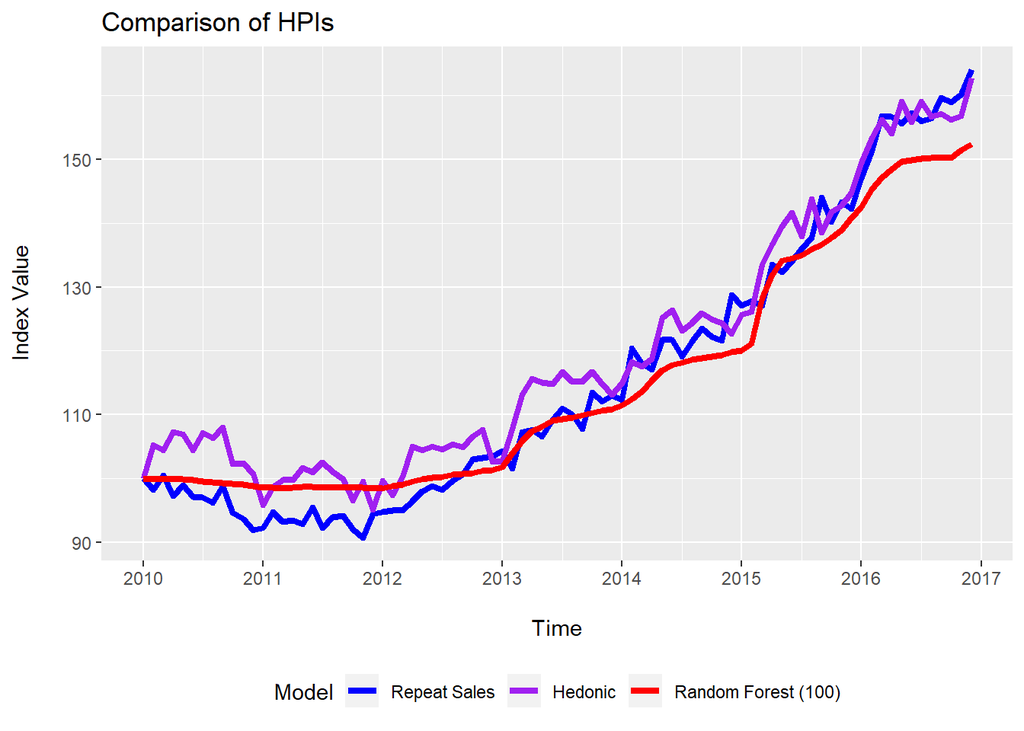

```r
 readRDS('c:/code/research/hpir/papers/rhrplot.rds')
```

### Full City, 2010 through 2016

```r
 full_df <- readRDS('c:/code/research/hpir/papers/full_summ.rds')
 names(full_df) <- c('Approach', "Volatility", 'Revision', 'Accuracy (In Sample)',
                     'Accuracy (kFold)', 'Accuracy (Prediction t+1)')
 full_df <- full_df[c(1,3,5), ]
 full_df$Approach <- c('Repeat Sales', 'Hedonic', 'Random Forest')
 knitr::kable(full_df, format = 'html', digits = 3, row.names = FALSE)
```

| Approach | Volatility | Revision | Accuracy (In Sample) | Accuracy (kFold) | Accuracy (Prediction t+1) |
| --- | --- | --- | --- | --- | --- |
| Repeat Sales | 0.022 | -0.664 | 0.095 | 0.116 | 0.160 |
| Hedonic | 0.023 | 0.009 | 0.095 | 0.097 | 0.095 |
| Random Forest | 0.004 | 0.215 | 0.111 | 0.107 | 0.104 |

### Small Geographic Areas

```r
 geo_df <- readRDS('c:/code/research/hpir/papers/geo_summ.rds')
 names(geo_df) <- c('Approach', "Volatility", 'Revision', 'Accuracy (In Sample)',
                     'Accuracy (kFold)', 'Accuracy (Prediction t+1)')
 geo_df <- geo_df[c(1,3,5), ]
 geo_df$Approach <- c('Repeat Sales', 'Hedonic', 'Random Forest')
 knitr::kable(geo_df, format = 'html', digits = 3, row.names = FALSE)
```

| Approach | Volatility | Revision | Accuracy (In Sample) | Accuracy (kFold) | Accuracy (Prediction t+1) |
| --- | --- | --- | --- | --- | --- |
| Repeat Sales | 0.119 | 0.128 | 0.122 | 0.201 | 0.210 |
| Hedonic | 0.061 | 0.008 | 0.101 | 0.109 | 0.103 |
| Random Forest | 0.003 | 0.077 | 0.102 | 0.104 | 0.103 |

### Short Time Frames

```r
 time_df <- readRDS('c:/code/research/hpir/papers/time_summ.rds')
 names(time_df) <- c('Approach', "Volatility", 'Revision', 'Accuracy (In Sample)',
                     'Accuracy (kFold)', 'Accuracy (Prediction t+1)')
 time_df <- time_df[c(1,3,5), ]
 time_df$Approach <- c('Repeat Sales', 'Hedonic', 'Random Forest')
 knitr::kable(time_df, format = 'html', digits = 3, row.names = FALSE)
```

| Approach | Volatility | Revision | Accuracy (In Sample) | Accuracy (kFold) | Accuracy (Prediction t+1) |
| --- | --- | --- | --- | --- | --- |
| Repeat Sales | 0.103 | 2.931 | 0.285 | 0.310 | 0.346 |
| Hedonic | 0.019 | 0.012 | 0.284 | 0.270 | 0.256 |
| Random Forest | 0.002 | 0.011 | 0.279 | 0.266 | 0.265 |

[^1]: A small amount of data cleaning has gone into the creating the data, for more information on this process please contact the author.